# Lab4

Skyler Moomey

2020-09-18

# Tasks

## Task 1

```r
getwd()
```

```
## [1] "/Users/skylermoomey/Desktop/MATH4753/Laboratories/Lab4"
```

## Task 2

```r
#spruce data frame
spruce.df <- read.csv("SPRUCE.csv")
names(spruce.df)[1] = "BHDiameter"

tail(spruce.df)
```

```
##    BHDiameter Height
## 31       17.7   19.9
## 32       20.7   19.4
## 33       21.0   20.4
## 34       13.3   15.5
## 35       15.9   17.6
## 36       22.9   19.2
```

## Task 3

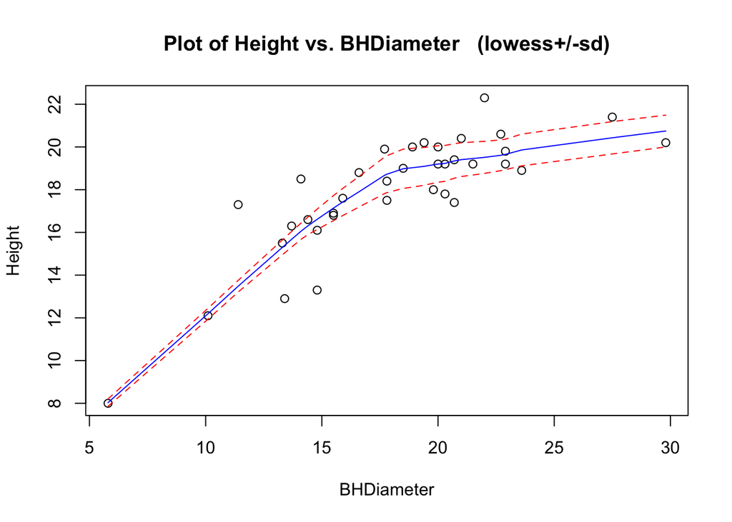

```r
library(s20x)

#lowess plot
trendscatter(Height~BHDiameter,f=0.5,data=spruce.df)
```

```r
# Now make the linear model
spruce.lm=lm(Height~BHDiameter,data=spruce.df)
summary(spruce.lm)
```

```
##
## Call:
## lm(formula = Height ~ BHDiameter, data = spruce.df)
##
## Residuals:
##     Min      1Q  Median      3Q     Max
## -3.9394 -0.9763  0.2829  0.9950  2.6644
##
## Coefficients:
##             Estimate Std. Error t value Pr(>|t|)
## (Intercept)  9.14684    1.12131   8.157 1.63e-09 ***
## BHDiameter   0.48147    0.05967   8.069 2.09e-09 ***
## ---
## Signif. codes:  0 '***' 0.001 '**' 0.01 '*' 0.05 '.' 0.1 ' ' 1
##
## Residual standard error: 1.678 on 34 degrees of freedom
## Multiple R-squared:  0.6569, Adjusted R-squared:  0.6468
## F-statistic:  65.1 on 1 and 34 DF,  p-value: 2.089e-09
```

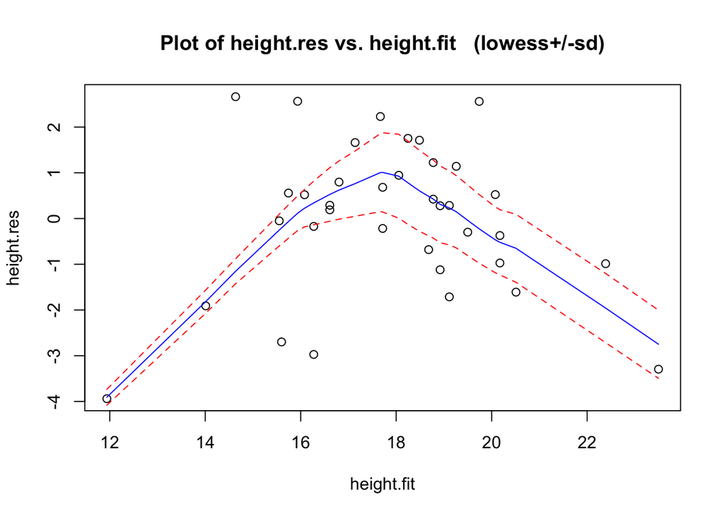

```r
height.res=residuals(spruce.lm) #residuals
height.fit=fitted(spruce.lm) #fitted values

#plot of residuals v. fitted
trendscatter(height.res~height.fit, f=0.5)
```

The residuals vs. fitted value make a very messy plot, and the trendscatter function tries to smooth them into a roughly quadratic shape, even though it barely fits the data. The model does not seem appropriate.

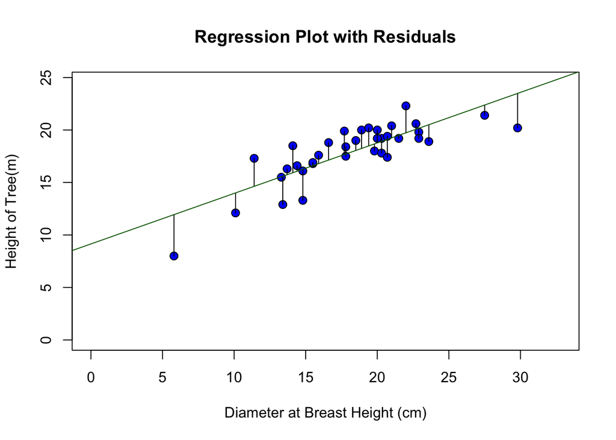

```r
with(data=spruce.df, plot(x=BHDiameter, y=Height, pch=21, ylab="Height of Tree(m)", xlab="Diameter at Breast Height (cm)", bg="blue",
                          ylim=c(0, 1.1*max(Height)), xlim=c(0, 1.1*max(BHDiameter)), cex=1.2))
title(main="Regression Plot with Residuals")
yhat=with(spruce.df, predict(spruce.lm, data.frame(BHDiameter)))
with(data=spruce.df, segments(BHDiameter, Height, BHDiameter, yhat))
abline(spruce.lm, col="dark green")
```

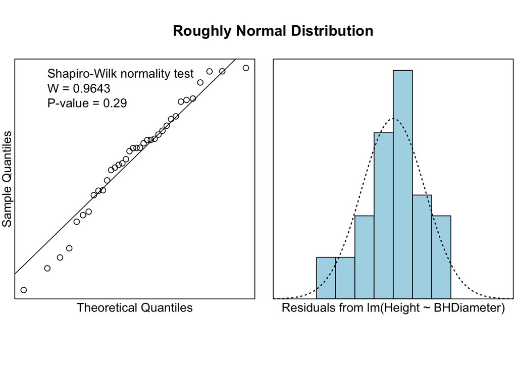

```r
normcheck(spruce.lm, shapiro.wilk = TRUE)
title(main="Roughly Normal Distribution")
```

```r
mean(height.res)
```

```
## [1] -3.087567e-17
```

```r
I(sd(height.res))^2
```

```
## [1] 2.734366
```

The p-value $=0.29$ for the linear model. This is much higher than the necessary $0.05$ to reject the null hypothesis. Additionally, the mean of the residuals is approximately $-3.09*10^{-17}$, extremely close to 0. $\sigma^2=2.734$ and so the linear model is validly applied to the SPRUCE data set, though there are still better models.

## Task 4

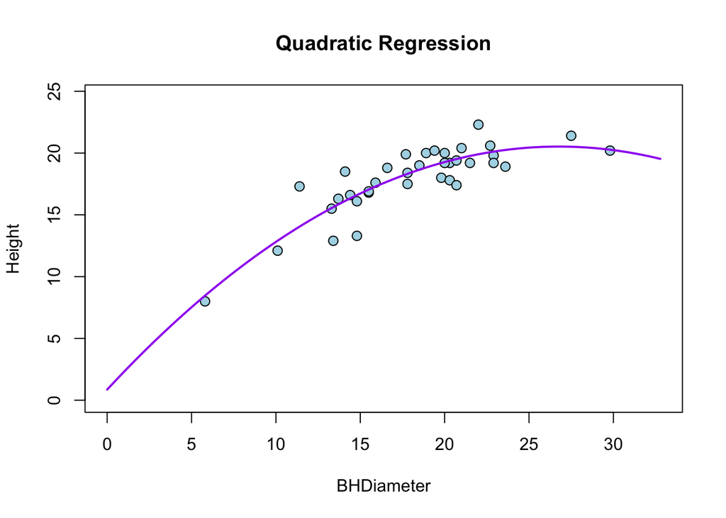

```r
## Quadratic object using the linear model
quad.lm=lm(Height~BHDiameter + I(BHDiameter^2),data=spruce.df)
quad.res=residuals(quad.lm)

with(spruce.df, plot(Height~BHDiameter, main="Quadratic Regression", pch=21, cex=1.2, ylim=c(0, 1.1*max(Height)), xlim=c(0, 1.1*max(BHDiameter)),
                                                                                                                         bg="light blue"))
#function to add quadratic curve to scatterplot
myplot=function(x){
 quad.lm$coef[1] +quad.lm$coef[2]*x  + quad.lm$coef[3]*x^2
}

curve(myplot, lwd=2, add=TRUE, col="purple")
```

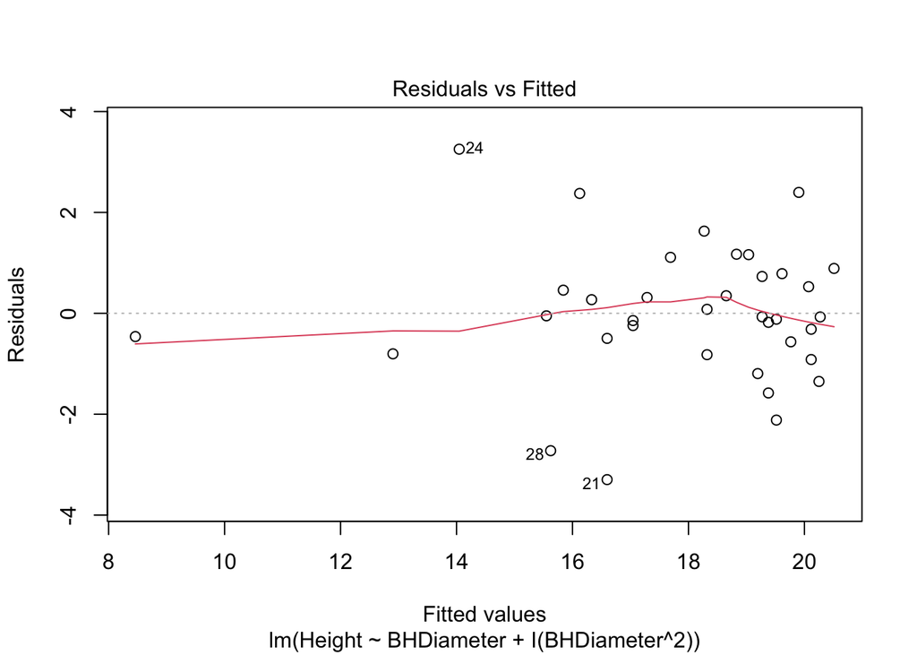

```r
plot(quad.lm, which=1)
```

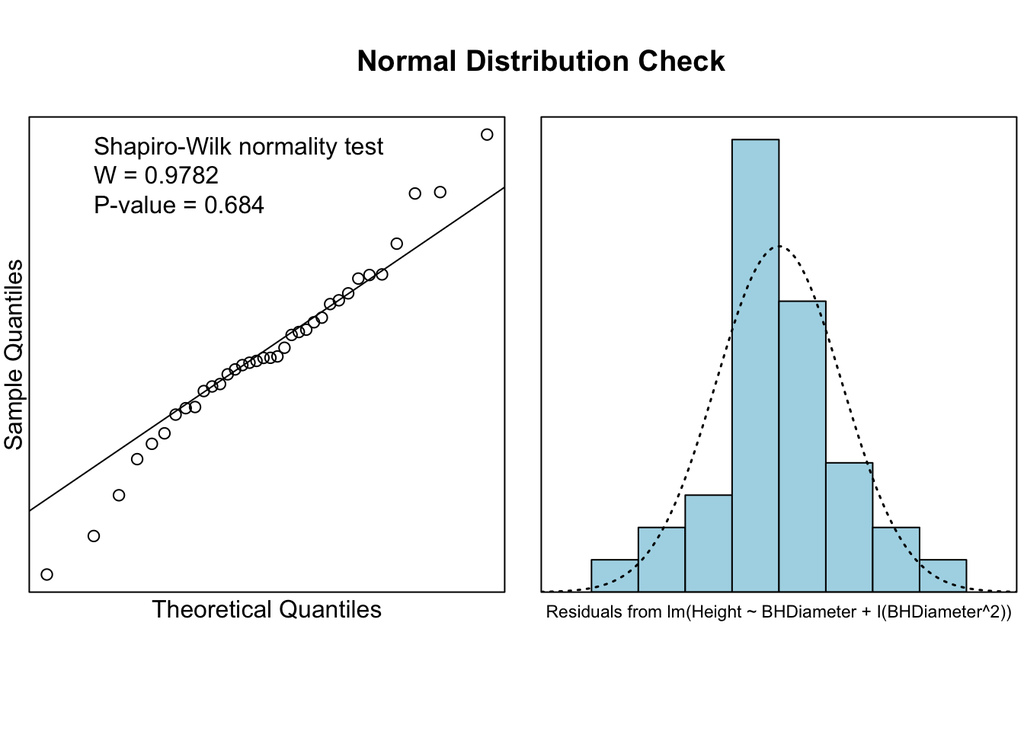

```r
normcheck(quad.lm, shapiro.wilk= TRUE)
title(main="Normal Distribution Check")
```

```r
mean(quad.res)
```

```
## [1] -3.469447e-17
```

```r
I(sd(quad.res))^2
```

```
## [1] 1.800195
```

The quadratic model’s p-value is 0.684, which allows us to accept the null hypothesis . The mean of the residuals is once again close to $0$, $\mu=-3.47*10^{-17}$, and $\sigma$ is constant, so the model is again a valid estimator of the data.

## Task 5

### Summary

```r
summary(quad.lm)
```

```
##
## Call:
## lm(formula = Height ~ BHDiameter + I(BHDiameter^2), data = spruce.df)
##
## Residuals:
##     Min      1Q  Median      3Q     Max
## -3.2966 -0.6245 -0.0707  0.7442  3.2541
##
## Coefficients:
##                  Estimate Std. Error t value Pr(>|t|)
## (Intercept)      0.860896   2.205022   0.390 0.698731
## BHDiameter       1.469592   0.243786   6.028 8.88e-07 ***
## I(BHDiameter^2) -0.027457   0.006635  -4.138 0.000227 ***
## ---
## Signif. codes:  0 '***' 0.001 '**' 0.01 '*' 0.05 '.' 0.1 ' ' 1
##
## Residual standard error: 1.382 on 33 degrees of freedom
## Multiple R-squared:  0.7741, Adjusted R-squared:  0.7604
## F-statistic: 56.55 on 2 and 33 DF,  p-value: 2.182e-11
```

### Coefficients

```r
coef(quad.lm)
```

```
##     (Intercept)      BHDiameter I(BHDiameter^2)
##      0.86089580      1.46959217     -0.02745726
```

$\hat{\beta_0}=0.860896\\ \hat{\beta_1}=1.469592\\ \hat{\beta_2}=-0.027457$

### Interval Estimates

```r
ciReg(quad.lm)
```

```
##                 95 % C.I.lower    95 % C.I.upper
## (Intercept)           -3.62525           5.34705
## BHDiameter             0.97361           1.96558
## I(BHDiameter^2)       -0.04096          -0.01396
```

### Equation of Fitted Line

$\hat{y}=0.86089580 + 1.46959217x+-0.02745726x^2$ where $\hat{y}$ is the estimate of the Height and $x$ corresponds to the Breast Height Diameter of a given sample.

### Some Predictions

```r
predict(quad.lm, data.frame(BHDiameter=c(15,18,20)))
```

```
##        1        2        3
## 16.72690 18.41740 19.26984
```

Let the quadratic model of the data be called $q$. Then,

$q(15)=16.72690\\q(18)=18.41740\\q(20)=19.26984$

### Multiple R-Squared

The multiple $R^2$ of the quadratic model is equivalent to $0.7741$. For the linear model, multiple $R^2$ is $0.6569$. Adjusted $R^2$ is, respectively $0.7604$ and $0.6468$. Because adjusted $R^2$ accounts for non-useful coeffecients, it can give a better idea of the variability explained by the curve. The quadratic model does a better job of this than the linear model. Multiple $R^2$, by contrast, shows the amount of variability in the dependent variable that is captured by the independent variable. However, because of the way $R^2$ is calculated, it will always increase when new terms are added to our linear model, even if they don’t actually make the estimate better. For this reason, adjusted $R^2$ can be a more “honest” estimate of the variability explained by a model with many terms.

### Anova

```r
anova(spruce.lm, quad.lm)
```

```
## Analysis of Variance Table
##
## Model 1: Height ~ BHDiameter
## Model 2: Height ~ BHDiameter + I(BHDiameter^2)
##   Res.Df    RSS Df Sum of Sq      F    Pr(>F)
## 1     34 95.703
## 2     33 63.007  1    32.696 17.125 0.0002269 ***
## ---
## Signif. codes:  0 '***' 0.001 '**' 0.01 '*' 0.05 '.' 0.1 ' ' 1
```

Model 2, the quadratic model, has a significantly smaller RSS value. I conclude that it better fits the model than does Model 1.

### MSS

```r
yhat2=with(spruce.df, predict(quad.lm, data.frame(BHDiameter)))
MSS=sum(I(yhat2-mean(spruce.df$Height))^2)
MSS
```

```
## [1] 215.9407
```

### RSS

```r
RSS=sum(I(quad.res)^2)
RSS
```

```
## [1] 63.00683
```

### TSS

```r
TSS=sum(I(spruce.df$Height-mean(spruce.df$Height))^2)
TSS
```

```
## [1] 278.9475
```

### Consistency check

```r
RSS + MSS
```

```
## [1] 278.9475
```

```r
TSS
```

```
## [1] 278.9475
```

### MSS/TSS

```r
I(MSS/TSS)
```

```
## [1] 0.7741266
```

## Task 6

### Cook’s Plot

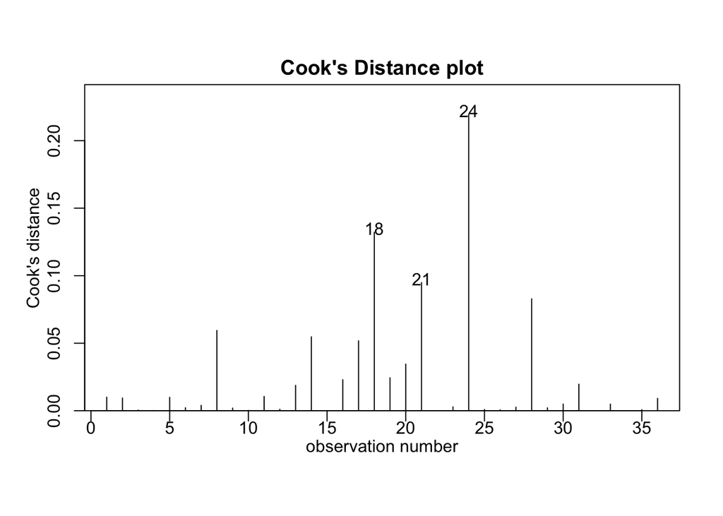

```r
cooks20x(quad.lm)
```

A Cook’s Distance is a combination of the residual for a particular datum as well as it’s leverage, i.e. how much influence it has on your model. As we can see, datum 24 has a particularly large Cook’s Distance relative to the other data points, and could potentially be skewing our model.

### Quadratic Model using BHDiameter$\backslash\{24\}$

```r
quad2.lm=lm(Height~BHDiameter + I(BHDiameter^2) , data=spruce.df[-24,])
summary(quad2.lm)
```

```
##
## Call:
## lm(formula = Height ~ BHDiameter + I(BHDiameter^2), data = spruce.df[-24,
##     ])
##
## Residuals:
##      Min       1Q   Median       3Q      Max
## -3.11233 -0.48227  0.01253  0.71727  2.59146
##
## Coefficients:
##                  Estimate Std. Error t value Pr(>|t|)
## (Intercept)     -0.341500   2.068479  -0.165     0.87
## BHDiameter       1.564793   0.226102   6.921 7.78e-08 ***
## I(BHDiameter^2) -0.029242   0.006114  -4.782 3.74e-05 ***
## ---
## Signif. codes:  0 '***' 0.001 '**' 0.01 '*' 0.05 '.' 0.1 ' ' 1
##
## Residual standard error: 1.266 on 32 degrees of freedom
## Multiple R-squared:  0.8159, Adjusted R-squared:  0.8044
## F-statistic: 70.91 on 2 and 32 DF,  p-value: 1.74e-12
```

The multiple $R^2$ of the new quadratic model is $0.8159$, versus the previous model’s $0.7741$. Removing the single datum associated with observation 24 improved the model’s accuracy by $0.8159-0.7741=0.0418$, approximately a $4\%$ improvement.

## Task 7

### Proof of Equation of Piecewise Function:

Let a line, call it $l1$, be given by the equation $\hat{y_1}=\beta_0 + \beta_1x$. Let a second line, $l2$, be given by the equation $\hat{y_2}=\gamma_0 + \gamma_1x$. Then, $\gamma_0$ is equal to $\beta_0$ plus some constant, say $\delta$, and $\gamma_1$ is equal $\beta_1$ plus some constant, say $\zeta$.

Then, we have that,

$\hat{y_1}=\beta_0+\beta_1x\\ \hat{y_2}=(\beta_0+\delta) + (\beta_1+\zeta)x.$

At some point on the domain of the two lines,we would like to have a change point $x_k$, which is the point at which the image of the function will be represented by $l2$ instead of $l1$.

Letting these two lines be equal at $x_k$, we find that,

$\beta_0+\beta_1x_k=\beta_0+\delta+(\beta_1+\zeta)x_k\\ \implies \beta_1x_k = \delta+\beta_1x_k+\zeta x_k\\ \implies \delta=-\zeta x_k$

Finally, we can write $l2$ as,

$\hat{y_2}=\beta_0+(\beta_1+\zeta)x-\zeta x_k\\ = \beta_0 + \beta_1x + \zeta(x-x_k)$.

We add the condition that $\tau (x-x_k)$ evaluates to $0$ when $x<x_k$ to get the equation of a piecewise function combining the two lines with change point $x_k$. Finally, we have that

$\hat{y}=\beta_0+\beta_1x+\zeta(x-x_k)I(x>x_k)$.

### Piecewise Regression

```r
sp2.df=within(spruce.df, X<-(BHDiameter-18)*(BHDiameter>18)) # this makes a new variable and places it within the same df

chgpoint=18

piecewise=lm(Height~BHDiameter + X, data=sp2.df)
summary(piecewise)
```

```
##
## Call:
## lm(formula = Height ~ BHDiameter + X, data = sp2.df)
##
## Residuals:
##     Min      1Q  Median      3Q     Max
## -3.1468 -0.5949 -0.1092  0.8366  3.5979
##
## Coefficients:
##             Estimate Std. Error t value Pr(>|t|)
## (Intercept)  4.49924    1.48621   3.027 0.004760 **
## BHDiameter   0.80727    0.09509   8.489 8.26e-10 ***
## X           -0.65408    0.16284  -4.017 0.000321 ***
## ---
## Signif. codes:  0 '***' 0.001 '**' 0.01 '*' 0.05 '.' 0.1 ' ' 1
##
## Residual standard error: 1.396 on 33 degrees of freedom
## Multiple R-squared:  0.7696, Adjusted R-squared:  0.7556
## F-statistic: 55.11 on 2 and 33 DF,  p-value: 3.032e-11
```

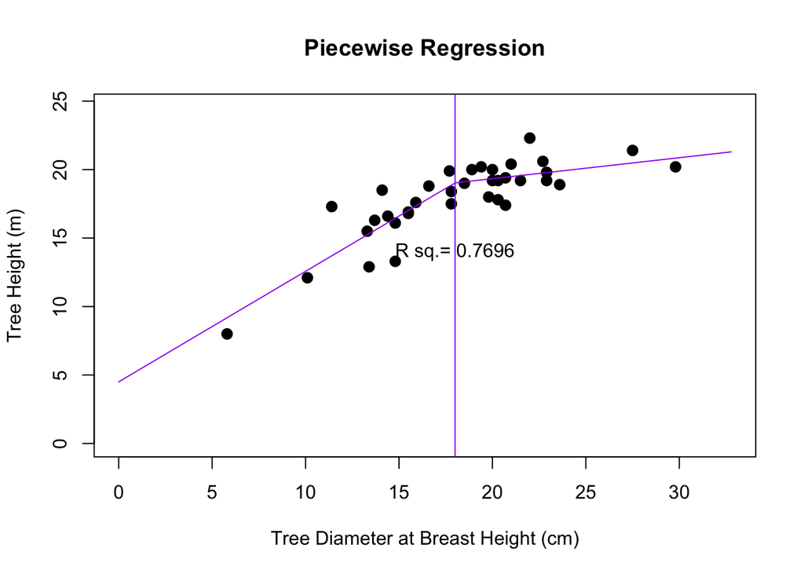

```r
#creates vector for plotting piecewise regression, (x>chgpoint) is the indicator term
piecefunc=function(x) {
  piecewise$coefficients[1]+piecewise$coefficients[2]*(x)+piecewise$coefficients[3]*(x-chgpoint)*(x>chgpoint)
}

with(spruce.df, plot(BHDiameter, Height, xlab= "Tree Diameter at Breast Height (cm)"
                     , ylab="Tree Height (m)", pch=21, bg="black", cex=1.2
                     , xlim=c(0, 1.1*max(BHDiameter)), ylim=c(0, 1.1*max(Height))))
title(main="Piecewise Regression")
abline(v=chgpoint, col="purple")
curve(piecefunc, add=TRUE, col="purple")
text(18,14,paste("R sq.=",round(summary(piecewise)$r.squared,4) ))
```

## Task 8

### Using Function from Personal R Package

```r
library(MATH4753moom0002)
```

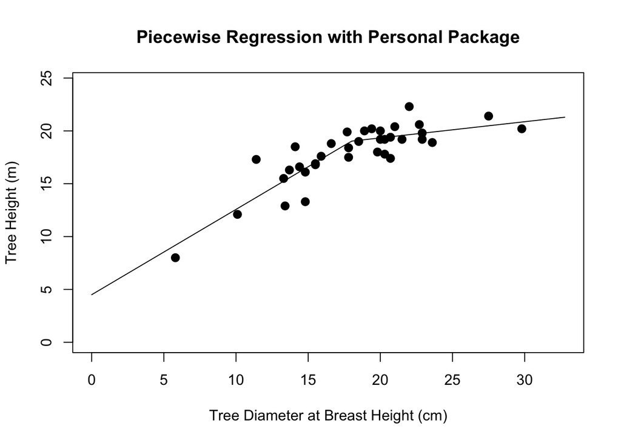

```r
with(spruce.df, plot(BHDiameter, Height, xlab= "Tree Diameter at Breast Height (cm)"
                     , ylab="Tree Height (m)", pch=21, bg="black", cex=1.2
                     , xlim=c(0, 1.1*max(BHDiameter)), ylim=c(0, 1.1*max(Height))))
title(main="Piecewise Regression with Personal Package")

curve(MATH4753moom0002::piecefunc(x, piecewise=piecewise, changepoint=chgpoint), add=TRUE)
```